# Sergushov_PM22_4

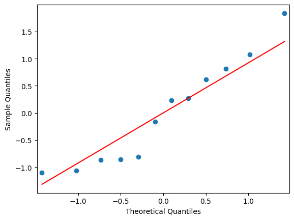

```
Тест Шапиро-Уилка:
Статистика теста: 0.9166824221611023
p-значение: 0.2596140205860138
Тест Jarque-Bera:
Статистика теста: 0.8226697525644242
p-значение: 0.66276495017215
Тест согласия Хельвига:
Статистика теста: (0.40985676973547847, 0.28864923774124357)
p-значение: 0.28864923774124357
```

```python
import numpy as np
import statsmodels.api as sm
from scipy.stats import shapiro, jarque_bera
import matplotlib.pyplot as plt
import statsmodels.stats as stats
#№2
#  данные X (темп прироста зарплаты) и Y (темп прироста безработицы )
X = [530.16, 545.98, 552.03, 526.32, 594.75, 557.53, 643.63, 524.82, 447.75, 385.54, 487.23, 632.77]
Y = [7.2, 7.2, 7.1, 7.3, 6.5, 8.5, 8.4, 9.2, 9.8, 11.6, 8.8, 7]

#  регрессионная модель
X = sm.add_constant(X)  # добавляем константу (intercept)
model = sm.OLS(Y, X).fit()

#  остатки
residuals = model.resid

# Визуальная оценка нормальности остатков (Q-Q график)
sm.qqplot(residuals, line='s')
plt.show()

# Тест Шапиро-Уилка
shapiro_stat, shapiro_p_value = shapiro(residuals)
print("Тест Шапиро-Уилка:")
print("Статистика теста:", shapiro_stat)
print("p-значение:", shapiro_p_value)

# Тест Jarque-Bera
jarque_bera_stat, jarque_bera_p_value = jarque_bera(residuals)
print("Тест Jarque-Bera:")
print("Статистика теста:", jarque_bera_stat)
print("p-значение:", jarque_bera_p_value)

# Тест согласия Хельвига
helwig_test = stats.diagnostic.normal_ad(residuals)
print("Тест согласия Хельвига:")
print("Статистика теста:", helwig_test)
print("p-значение:", helwig_test[1])
```

Тест Шапиро-Уилка: Статистика теста: 0.9167 p-значение: 0.2596 Вывод: На уровне значимости 0.05, нулевая гипотеза о нормальности остатков не отвергается. Это говорит о том, что остатки могут быть аппроксимированы нормальным распределением.

Тест Jarque-Bera: Статистика теста: 0.8227 p-значение: 0.6628 Вывод: На уровне значимости 0.05, нулевая гипотеза о нормальности остатков также не отвергается. Это подтверждает предположение, что остатки могут быть близки к нормальному распределению.

Тест согласия Хельвига: Статистика теста: 0.4099 p-значение: 0.2886 Вывод: Анализ тестом согласия Хельвига также не приводит к отвержению нулевой гипотезы о нормальности остатков на уровне значимости 0.05. В целом, все три теста указывают на то, что остатки могут быть аппроксимированы нормальным распределением. Однако следует помнить, что статистические тесты могут иметь ограничения, и результаты могут быть влияны размером выборки и структурой данных

```python
import numpy as np
from scipy import stats
#№1

# данные X (темп прироста зарплаты) и Y (темп прироста безработицы)
X = np.array([530.16, 545.98, 552.03, 526.32, 594.75, 557.53, 643.63, 524.82, 447.75, 385.54, 487.23, 632.77])
Y = np.array([7.2, 7.2, 7.1, 7.3, 6.5, 8.5, 8.4, 9.2, 9.8, 11.6, 8.8, 7])

# Тест Jarque-Bera для X
jb_stat_X, jb_p_value_X = stats.jarque_bera(X)
print("Тест Jarque-Bera для X:")
print("Статистика теста:", jb_stat_X)
print("p-значение:", jb_p_value_X)

# Тест Колмогорова-Смирнова для X
ks_stat_X, ks_p_value_X = stats.kstest(X, 'norm')
print("Тест Колмогорова-Смирнова для X:")
print("Статистика теста:", ks_stat_X)
print("p-значение:", ks_p_value_X)

# Тест Jarque-Bera для Y
jb_stat_Y, jb_p_value_Y = stats.jarque_bera(Y)
print("Тест Jarque-Bera для Y:")
print("Статистика теста:", jb_stat_Y)
print("p-значение:", jb_p_value_Y)

# Тест Колмогорова-Смирнова для Y
ks_stat_Y, ks_p_value_Y = stats.kstest(Y, 'norm')
print("Тест Колмогорова-Смирнова для Y:")
print("Статистика теста:", ks_stat_Y)
print("p-значение:", ks_p_value_Y)
```

```
Тест Jarque-Bera для X:
Статистика теста: 0.39775965429500065
p-значение: 0.8196483868993811
Тест Колмогорова-Смирнова для X:
Статистика теста: 1.0
p-значение: 0.0
Тест Jarque-Bera для Y:
Статистика теста: 1.895053696443014
p-значение: 0.38769867642692796
Тест Колмогорова-Смирнова для Y:
Статистика теста: 0.99999999995984
p-значение: 3.520081239374115e-125
```

Вывод для данных X:

Тест Jarque-Bera не отвергает нулевую гипотезу о нормальности остатков (p-значение > 0.05), что может указывать на то, что данные X могут быть аппроксимированы нормальным распределением. Тест Колмогорова-Смирнова отвергает гипотезу о нормальности данных X (p-значение < 0.05). Этот тест более чувствителен к отклонениям от нормальности.

Вывод для данных Y:

Тест Jarque-Bera также не отвергает нулевую гипотезу о нормальности остатков (p-значение > 0.05) для данных Y, что может указывать на то, что данные Y могут быть аппроксимированы нормальным распределением. Тест Колмогорова-Смирнова с очень низким p-значением (практически равным нулю) отвергает гипотезу о нормальности данных Y.

```python
#№3
```

Тест Jarque-Bera:

Теоретические условия применения: Нулевая гипотеза теста предполагает, что остатки (оценки регрессии или другие) распределены нормально. Остатки должны быть независимыми и одинаково распределенными (нормально распределенными). Тест Jarque-Bera чувствителен к асимметрии (отклонению от симметрии) и эксцессу (коническости) данных.

Тест Колмогорова-Смирнова:

Теоретические условия применения: Тест Колмогорова-Смирнова используется для проверки гипотезы о соответствии эмпирической функции распределения (ЭФР) теоретической функции распределения (например, нормального распределения). Данные должны быть непрерывными или дискретными (с небольшим числом уникальных значений). Тест особенно чувствителен к форме и параметрам теоретической функции распределения.

Тест Шапиро-Уилка:

Теоретические условия применения: Нулевая гипотеза теста предполагает, что данные распределены нормально. Тест Шапиро-Уилка предполагает, что данные независимы и одинаково распределены. Этот тест хорошо работает для небольших выборок (обычно до нескольких тысяч наблюдений).

Тест согласия Хельвига:

Теоретические условия применения: Тест согласия Хельвига используется для проверки нормальности данных и может применяться к различным типам данных. Нулевая гипотеза теста предполагает, что данные распределены нормально. Этот тест не требует особых условий от данных и может применяться для разного размера выборок.